# Answer 01 - Siddhesh Shinde

```r
# Load required packages
library(tidyverse)
library(knitr)
library(kableExtra)
```

```r
library(moments)
library(ggplot2)
library(dplyr)
library(seedhash)

# Set reproducible seed
gen <- SeedHashGenerator$new("Siddhesh")
seeds <- gen$generate_seeds(5)
set.seed(seeds[2])
```

The structure of the data and a preview of the data.

```r
iris_data <- read.csv("iris_exams.csv")

# Display basic information
cat("Dataset successfully loaded!\n")
```

```
## Dataset successfully loaded!
```

```r
cat("Number of rows:", nrow(iris_data), "\n")
```

```
## Number of rows: 300
```

```r
cat("Number of columns:", ncol(iris_data), "\n")
```

```
## Number of columns: 6
```

```r
# Structure of the data
str(iris_data)
```

```
## 'data.frame':    300 obs. of  6 variables:
##  $ id          : chr  "S001" "S002" "S003" "S004" ...
##  $ Species     : chr  "setosa" "setosa" "setosa" "setosa" ...
##  $ Sepal.Length: num  4.75 5.07 5.24 5.48 4.9 ...
##  $ Sepal.Width : num  3.3 3.68 3.44 3.96 2.81 ...
##  $ Petal.Length: num  1.44 1.21 1.59 1.53 1.49 ...
##  $ Petal.Width : num  0.235 0.111 0.405 0.272 0.345 ...
```

```r
cat("\nColumn names:\n")
```

```
##
## Column names:
```

```r
print(names(iris_data))
```

```
## [1] "id"           "Species"      "Sepal.Length" "Sepal.Width"  "Petal.Length"
## [6] "Petal.Width"
```

```r
cat("\nData types summary:\n")
```

```
##
## Data types summary:
```

```r
sapply(iris_data, class)
```

```
##           id      Species Sepal.Length  Sepal.Width Petal.Length  Petal.Width
##  "character"  "character"    "numeric"    "numeric"    "numeric"    "numeric"
```

```r
# First 6 rows
head(iris_data) %>%
  kable(caption = "First 6 Rows of Iris Dataset") %>%
  kable_styling(bootstrap_options = c("striped", "hover"))
```

First 6 Rows of Iris Dataset

| id | Species | Sepal.Length | Sepal.Width | Petal.Length | Petal.Width |
| --- | --- | --- | --- | --- | --- |
| S001 | setosa | 4.746510 | 3.301532 | 1.441511 | 0.2348507 |
| S002 | setosa | 5.072022 | 3.678133 | 1.208144 | 0.1114255 |
| S003 | setosa | 5.241044 | 3.442049 | 1.585426 | 0.4054026 |
| S004 | setosa | 5.475311 | 3.960215 | 1.533434 | 0.2724266 |
| S005 | setosa | 4.900481 | 2.806450 | 1.486378 | 0.3452578 |
| S006 | setosa | 5.580621 | 3.857734 | 1.875316 | 0.3060997 |

```r
# Last 6 rows
tail(iris_data) %>%
  kable(caption = "Last 6 Rows of Iris Dataset") %>%
  kable_styling(bootstrap_options = c("striped", "hover"))
```

Last 6 Rows of Iris Dataset

|  | id | Species | Sepal.Length | Sepal.Width | Petal.Length | Petal.Width |
| --- | --- | --- | --- | --- | --- | --- |
| 295 | S295 | virginica | 6.420805 | 2.605291 | 5.438116 | 1.901885 |
| 296 | S296 | virginica | 6.718278 | 3.046628 | 5.997826 | 2.097364 |
| 297 | S297 | virginica | 6.398033 | 2.889845 | 5.206807 | 1.977526 |
| 298 | S298 | virginica | 6.965135 | 3.010309 | 5.946944 | 2.422499 |
| 299 | S299 | virginica | 6.253522 | 2.558635 | 5.585143 | 1.732517 |
| 300 | S300 | virginica | 5.449870 | 2.400979 | 5.001774 | 1.596633 |

Frequency Distribution. (Frequency Tables & Plots for each variable in the dataset (Barplots/Histograms)). Make sure to capture the skewness and kurtosis. - Provide an interpretation in one paragraph (no more than 300 words) explaining the distribution of the data.

```r
# Frequency table
if("Species" %in% names(iris_data)) {
  species_freq <- table(iris_data$Species)
  cat("\nFrequency Table for Species:\n")
  print(species_freq)

  species_freq_df <- as.data.frame(species_freq)
  colnames(species_freq_df) <- c("Species", "Frequency")

  species_freq_df %>%
    kable(caption = "Frequency Distribution of Species") %>%
    kable_styling(bootstrap_options = c("striped", "hover"), full_width = FALSE)
}
```

```
##
## Frequency Table for Species:
##
##     setosa versicolor  virginica
##        100        100        100
```

Frequency Distribution of Species

| Species | Frequency |
| --- | --- |
| setosa | 100 |
| versicolor | 100 |
| virginica | 100 |

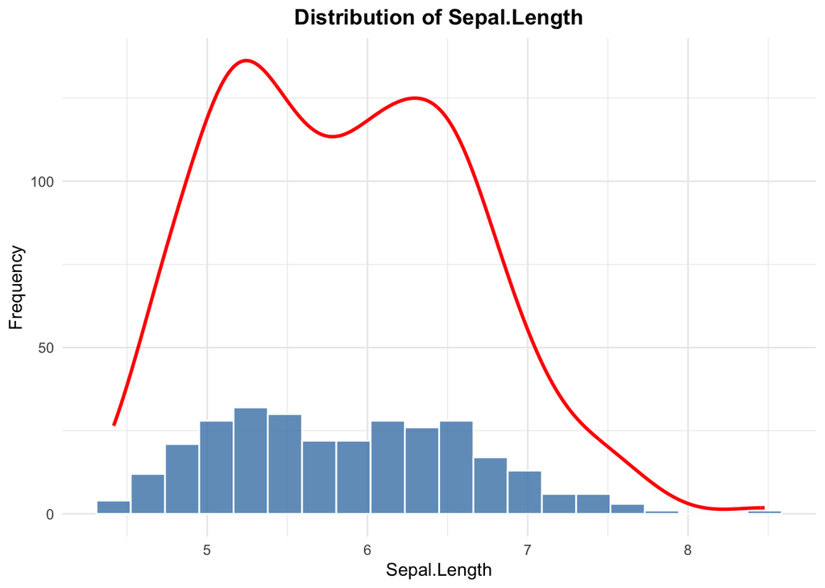

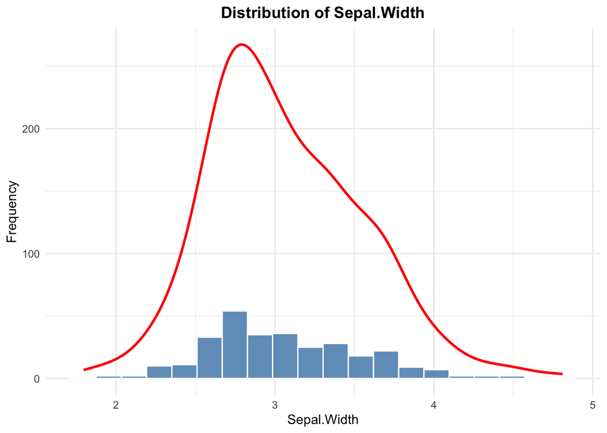

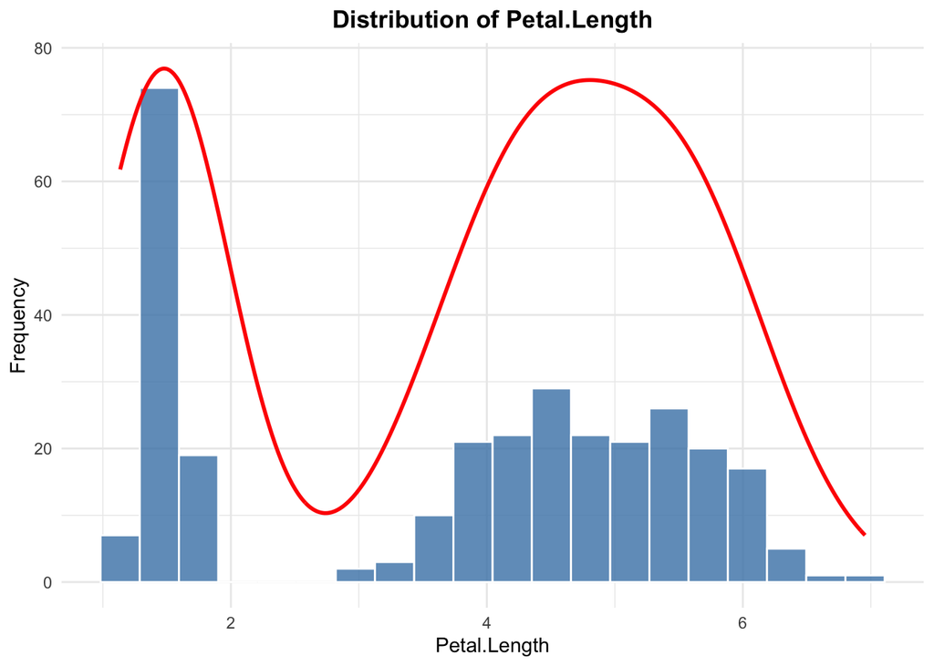

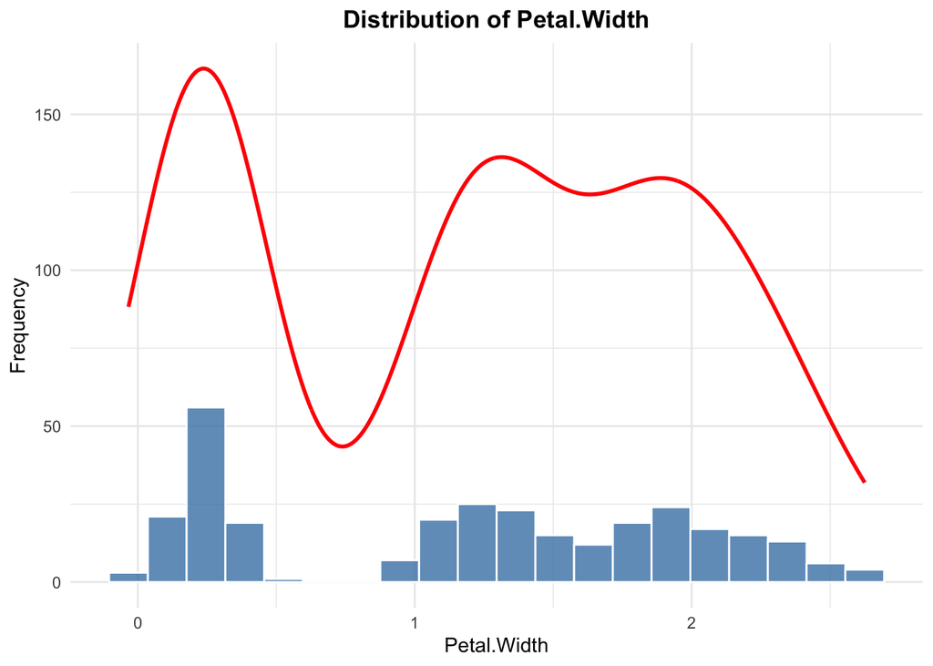

```r
# Histogram
numeric_cols <- names(iris_data)[sapply(iris_data, is.numeric)]

for(col in numeric_cols) {
  p <- ggplot(iris_data, aes_string(x = col)) +
    geom_histogram(bins = 20, fill = "steelblue", color = "white", alpha = 0.8) +
    geom_density(aes(y = ..count..), color = "red", linewidth = 1) +
    labs(title = paste("Distribution of", col),
         x = col,
         y = "Frequency") +
    theme_minimal() +
    theme(plot.title = element_text(hjust = 0.5, face = "bold"))

  print(p)
}
```

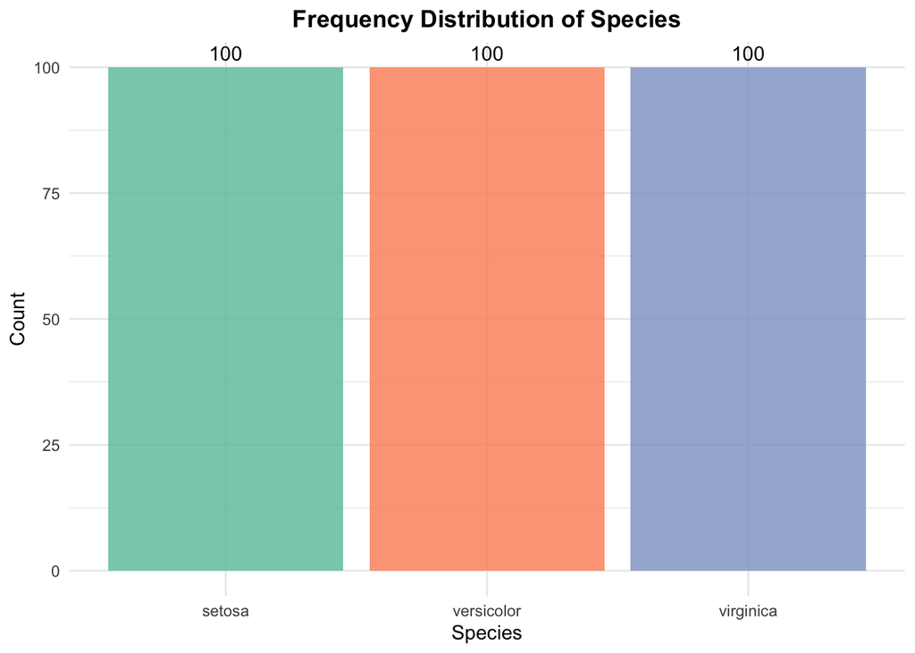

```r
# Barplot

if("Species" %in% names(iris_data)) {
  ggplot(iris_data, aes(x = Species, fill = Species)) +
    geom_bar(alpha = 0.8) +
    geom_text(stat = 'count', aes(label = ..count..), vjust = -0.5) +
    labs(title = "Frequency Distribution of Species",
         x = "Species",
         y = "Count") +
    theme_minimal() +
    theme(plot.title = element_text(hjust = 0.5, face = "bold"),
          legend.position = "none") +
    scale_fill_brewer(palette = "Set2")
}
```

```r
# Skewness and Kurtosis

skew_kurt_results <- data.frame(
  Variable = numeric_cols,
  Skewness = sapply(numeric_cols, function(col) skewness(iris_data[[col]], na.rm = TRUE)),
  Kurtosis = sapply(numeric_cols, function(col) kurtosis(iris_data[[col]], na.rm = TRUE))
)

rownames(skew_kurt_results) <- NULL

skew_kurt_results %>%
  kable(caption = "Skewness and Kurtosis Statistics", digits = 3) %>%
  kable_styling(bootstrap_options = c("striped", "hover"), full_width = FALSE)
```

Skewness and Kurtosis Statistics

| Variable | Skewness | Kurtosis |
| --- | --- | --- |
| Sepal.Length | 0.322 | 2.511 |
| Sepal.Width | 0.506 | 3.299 |
| Petal.Length | -0.274 | 1.559 |
| Petal.Width | -0.061 | 1.653 |

```r
for (i in 1:nrow(skew_kurt_results)) {
  var_name <- skew_kurt_results$Variable[i]
  skewness_val <- skew_kurt_results$Skewness[i]
  kurtosis_val <- skew_kurt_results$Kurtosis[i]

  cat("\n", var_name, ":\n", sep = "")

  # Skewness interpretation
  cat("Interpretation:",
    ifelse(abs(skewness_val) < 0.5, "Approximately Symmetric",
           ifelse(skewness_val > 0, "Right-skewed (Positive)", "Left-skewed (Negative)")), "\n")

  # Kurtosis interpretation
  cat("Interpretation:",
    ifelse(kurtosis_val > 3, "Leptokurtic (heavy tails)",
           ifelse(kurtosis_val < 3, "Platykurtic (light tails)", "Mesokurtic (normal)")), "\n")

  cat("\n")
}
```

```
##
## Sepal.Length:
## Interpretation: Approximately Symmetric
## Interpretation: Platykurtic (light tails)
##
##
## Sepal.Width:
## Interpretation: Right-skewed (Positive)
## Interpretation: Leptokurtic (heavy tails)
##
##
## Petal.Length:
## Interpretation: Approximately Symmetric
## Interpretation: Platykurtic (light tails)
##
##
## Petal.Width:
## Interpretation: Approximately Symmetric
## Interpretation: Platykurtic (light tails)
```

Summary Statistics of the Data at least including mean, quartiles, min/max, and standard deviation.

```r
summary(iris_data)
```

```
##       id              Species           Sepal.Length    Sepal.Width
##  Length:300         Length:300         Min.   :4.417   Min.   :1.796
##  Class :character   Class :character   1st Qu.:5.209   1st Qu.:2.720
##  Mode  :character   Mode  :character   Median :5.844   Median :2.992
##                                        Mean   :5.857   Mean   :3.064
##                                        3rd Qu.:6.448   3rd Qu.:3.375
##                                        Max.   :8.478   Max.   :4.810
##   Petal.Length    Petal.Width
##  Min.   :1.135   Min.   :-0.03371
##  1st Qu.:1.566   1st Qu.: 0.30278
##  Median :4.228   Median : 1.28776
##  Mean   :3.738   Mean   : 1.19830
##  3rd Qu.:5.205   3rd Qu.: 1.87452
##  Max.   :6.955   Max.   : 2.62487
```

```r
# More detailed summary by species
iris_detailed <- iris_data %>%
  group_by(Species) %>%
  summarise(
    N = n(),
    Mean_Sepal_Length = mean(Sepal.Length),
    SD_Sepal_Length = sd(Sepal.Length),
    Mean_Sepal_Width = mean(Sepal.Width),
    SD_Sepal_Width = sd(Sepal.Width),
    Mean_Petal_Length = mean(Petal.Length),
    SD_Petal_Length = sd(Petal.Length)
  ) %>%
  mutate(across(where(is.numeric), ~round(., 2)))

iris_detailed %>%
  kable(caption = "Detailed Summary by Species") %>%
  kable_styling(bootstrap_options = c("striped", "hover")) %>%
  scroll_box(width = "100%")
```

Detailed Summary by Species

| Species | N | Mean_Sepal_Length | SD_Sepal_Length | Mean_Sepal_Width | SD_Sepal_Width | Mean_Petal_Length | SD_Petal_Length |
| --- | --- | --- | --- | --- | --- | --- | --- |
| setosa | 100 | 5.09 | 0.31 | 3.55 | 0.39 | 1.48 | 0.14 |
| versicolor | 100 | 5.99 | 0.55 | 2.72 | 0.29 | 4.22 | 0.50 |
| virginica | 100 | 6.49 | 0.61 | 2.93 | 0.32 | 5.51 | 0.50 |

DISTRIBUTION INTERPRETATION:

The given Iris dataset contains measurements of flower characteristics across 3 different species (Setosa, Versicolor and Virginica). The numerical variables (Sepal Length, Sepal Width, Petal Length, and Petal Width) show varying degrees of skewness and kurtosis. Based on the frequency distribution histogram, the variable Sepal Width is the only variable with single peak whereas rest of the variables have multipeaks. As for the skewness and kurtosis test, the Sepal Width variable was again an odd man out with being right-skewed and having heavy tails whereas rest all variables have approximitly symmetric skewness and light tails.